# Lab 24: Chicago Crime Data II

## Instructions

Below you will find several empty R code scripts and answer prompts. Your task is to fill in the required code snippets and answer the corresponding questions.

## Chicago Crime Data

Today we are going to look at a fairly largerdataset. Each row of the data refers to a single reported crime in the City of Chicago:

The available variable are:

- `area_number`: the community area code of the crime; a number from 1-77
- `arrest_flag`: whether the crime resulted in an arrest; 0 is false and 1 is true
- `domestic_flag`: whether the crime is classified as a domestic offense; 0 is false and 1 is true
- `night_flag`: did the crime occur at night (9pm - 3am); 0 is false and 1 is true
- `burglary`: was the crime classified as a burglary? 0 is false and 1 is true
- `theft`: was the crime classified as a theft? 0 is false and 1 is true
- `battery`: was the crime classified as a battery? 0 is false and 1 is true
- `damage`: was the crime classified as a damage? 0 is false and 1 is true
- `assault`: was the crime classified as an assault? 0 is false and 1 is true
- `deception`: was the crime classified as criminal deception? 0 is false and 1 is true
- `robbery`: was the crime classified as a robbery? 0 is false and 1 is true
- `narcotics`: was the crime classified as a narcotics violation? 0 is false and 1 is true

We also have metadata about each community area within Chicago as well. We will see how to use these shortly.

- `area_number`: the community area code; a number from 1 to 77
- `area_name`: popular name of the community area
- `median_age`: the median age of all residents in the community area
- `num_households`: total number of households
- `family_households`: percentage of households classified as a `family’ (domestic partners, married couples, and one or more parents with children)
- `family_w_kids`: percentage of households with children under the age of 18
- `owner_ratio`: ratio of households that own or mortgage their primary residence
- `mean_travel_time`: average commute time
- `percent_walk`: percentage of commuters who walk to work (0-100)
- `median_income`: median household income
- `perc_20_units`: percentage of residential buildings with 20 or more units

As before, it will be useful to group summarize the dataset and join the metadata. Do that here to construct the dataset `crimes_ca`:

### Example

Last time, I said that it may be useful to summarize the dataset it in a different way. This will be a powerful tool in Project D. To test your knowledge of what this means, look at this dataset and plot:

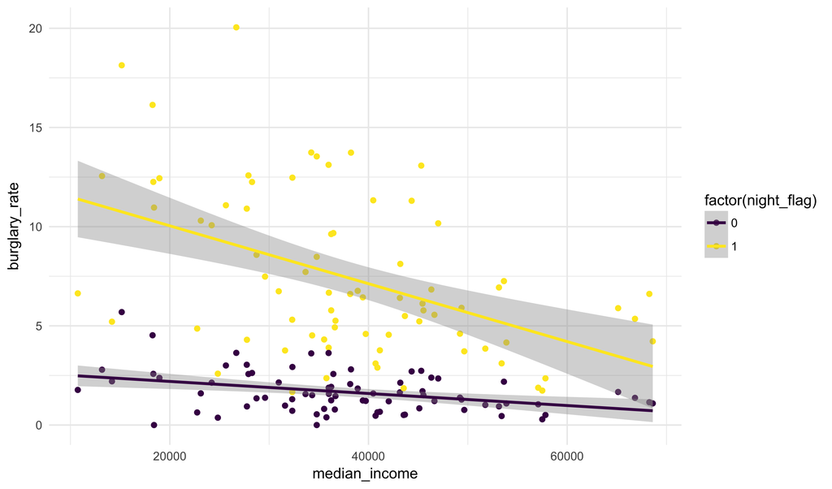

How many observations are there in the data? What does one row represent? How do you interpret the plot? Do the two slopes differ; what does this mean in practical terms?

### Prompts

Address one of the following prompts. Your end goal should be to produce a data visualization (make sure to include labels) and a 1-2 sentence thesis statement. Straight from Wikipedia, a thesis statement: “offers a concise summary of the main point or claim of the essay, research paper, ect.” Note, these questions are jumping off points. You can deviate or extend from them if something related strikes your interest.

1. How is the rate of battery crimes (that is the number of crimes per household) effected by how central a neighborhood is to the city of Chicago? Centrality can be measured by several variables, including the percentage of people who walk to work, number of households living in buildings with 20+ units, or total commute time. You may want to differentiate between crimes at night and those during the day.
2. What proportion of narcotics violations result in an arrest by neighborhood? Do any features of a neighborhood seem to effect this rate? If you see any outliers try to document and explain these.
3. What is the relationship between the overall arrest rate and the crime rate in a given neighborhood? Does income effect or correlate with these in any expected or unexpected ways?
4. How does the relationship between income and the rate of burglaries change between day and nighttime? You may want to highlight 1-2 particular neighborhoods to make your point.
5. Robbery and theft are similar crimes, the difference being that robbery involves taking something by force whereas theft is simply the taking of another’s property. Considering only crimes at night, how does the ratio of robberies to the number robberies and thefts relate to demographics in each neighborhood. Try to find a particularly interesting or predictive demographic.
6. There are 6 community areas where over 47% of households have children. How does the relationship between the number of crimes that occur and night and the arrest rate in each neighborhood compare between these 9 areas and the others?
7. How does the relationship between income and the rate of assault change between day and nighttime? You may want to highlight any particularly interesting outliers.

### Exploratory Analysis

Write you exploratory analysis here:

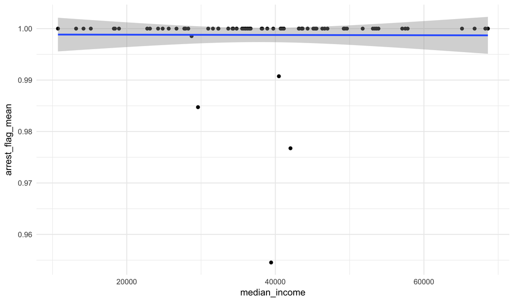

Almost all of the narcotics are arrested in all neighborhoods.